# Making a model

by Craig Slinkman

10/16/2020

Predace

This is Craig Slinkman’s implementation of the tutorial of how to use the tidyverse to carry out systematic model building based on the online tutorial [Build a Model](https://www.tidymodels.org/start/models/). My implementation will be based on my R-coding style. Any errors are my fault.

This is the first part the tidymodels tutorial.

## Introduction 🔗︎

How do you create a statistical model using tidymodels? In this article, we will walk you through the steps. We start with data for modeling, learn how to specify and train models with different engines using the parsnip package, and understand why these functions are designed this way.

To use code in this article, you will need to install the following packages: broom.mixed, readr, rstanarm, and tidymodels.

We load the required packages below:

```r
require( tidyverse )          # I live in the tidyverse.
require( tidymodels )         # For model building support.
```

```r
require( readr )              # To read a csv file into a tibble.
require( cowplot )            # For professional grahics.
require( broom.mixed )        # for converting bayesian models to tidy tibble.
require( rstanarm )           # For Bayesian analysis.
```

## The Sea Urchins Data

Let’s use the data from [Constable (1993)](https://link.springer.com/article/10.1007/BF00349318) to explore how three different feeding regimes affect the size of sea urchins over time. The initial size of the sea urchins at the beginning of the experiment probably affects how big they grow as they are fed.

To start, let’s read our urchins data into R, which we’ll do by providing readr::read_csv() with a url where our CSV data is located (“https://tidymodels.org/start/models/urchins.csv”):

```r
################################################################################
# In this chunk we:
#
#   1. Read the data ...
#   2  Change the column names to make them more intelligible ...
#   3. Make the column food_regime from a cgaracter column to an R
#      factor
################################################################################

fp <-                                                 # Set file path.
  "https://tidymodels.org/start/models/urchins.csv"

urchins <-
  read_csv( fp ) %>%
    setNames( c( "food_regime",
                 "initial_volume",
                 "width" )) %>%
     mutate(food_regime = factor( food_regime,
                                  levels = c("Initial",
                                             "Low",
                                             "High")))
```

To ensure we have not made a mistake we display the tibble:

```r
urchins
```

```
## # A tibble: 72 x 3
##    food_regime initial_volume width
##    <fct>                <dbl> <dbl>
##  1 Initial                3.5 0.01
##  2 Initial                5   0.02
##  3 Initial                8   0.061
##  4 Initial               10   0.051
##  5 Initial               13   0.041
##  6 Initial               13   0.061
##  7 Initial               15   0.041
##  8 Initial               15   0.071
##  9 Initial               16   0.092
## 10 Initial               17   0.051
## # ... with 62 more rows
```

The urchins data is a [tibble](https://tibble.tidyverse.org/index.html). If you are new to tibbles, the best place to start is the [tibbles chapter](https://r4ds.had.co.nz/tibbles.html) in *R for Data Science*. For each of the 72 urchins, we know their:

- experimental feeding regime group (food_regime: either Initial, Low, or High),
- size in milliliters at the start of the experiment (initial_volume),
- and suture width at the end of the experiment (width).

The first think we should do in a data analysis is to plot it:

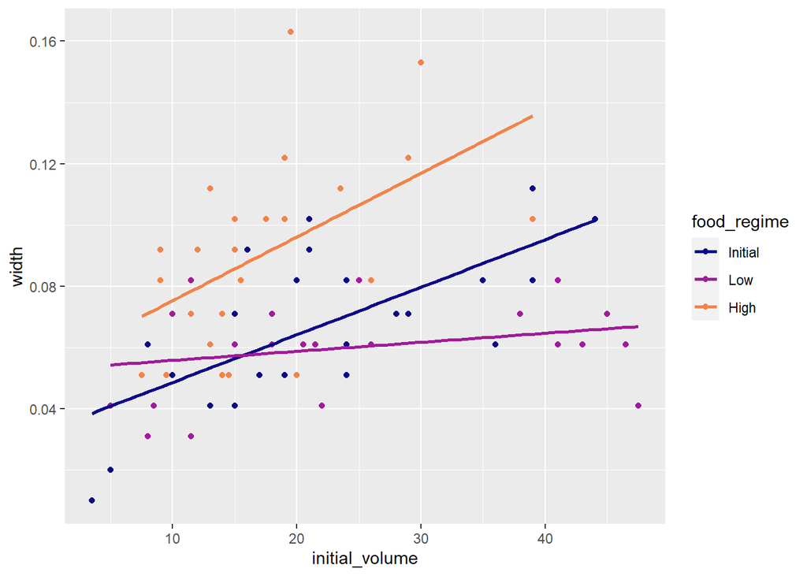

```r
ggplot(urchins,
       aes(x = initial_volume,
           y = width,
           group = food_regime,
           col = food_regime)) +
  geom_point() +
  geom_smooth(method = lm, se = FALSE) +
  scale_color_viridis_d(option = "plasma", end = .7)
```

Opps! I forgot to set the cowplot them.

```r
theme_set(theme_cowplot())
```

Redrawing the above plot we get:

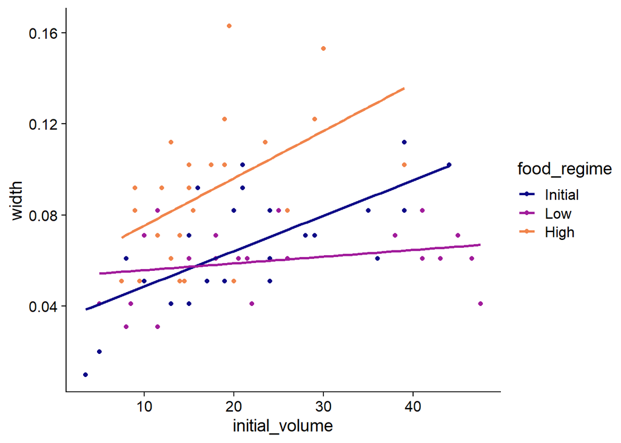

```r
ggplot(urchins,
       aes(x = initial_volume,
           y = width,
           group = food_regime,
           col = food_regime)) +
  geom_point() +
  geom_smooth(method = lm, se = FALSE) +
  scale_color_viridis_d(option = "plasma", end = .7)
```

We can see that urchins that were larger in volume at the start of the experiment tended to have wider sutures at the end, but the slopes of the lines look different so this effect may depend on the feeding regime condition.

## Build and fit a model 🔗︎ 4

A standard two-way analysis of variance (ANOVA) model makes sense for this dataset because we have both a continuous predictor and a categorical predictor. Since the slopes appear to be different for at least two of the feeding regimes, let’s build a model that allows for two-way interactions. Specifying an R formula with our variables in this way:

```
width ~ initial_volume * food_regime
```

allows our regression model depending on initial volume to have separate slopes and intercepts for each food regime.

For this kind of model, ordinary least squares is a good initial approach. With tidymodels, we start by specifying the functional form of the model that we want using the parsnip package. Since there is a numeric outcome and the model should be linear with slopes and intercepts, the model type is “linear regression”. We can declare this with:

```
linear_reg()
```

That is pretty underwhelming since, on its own, it doesn’t really do much. However, now that the type of model has been specified, a method for fitting or training the model can be stated using the ##engine##. The engine value is often a mash-up of the software that can be used to fit or train the model as well as the estimation method. For example, to use ordinary least squares, we can set the engine to be lm:

```
linear_reg() %>%
  set_engine("lm")
```

The [documentation page for linear_reg()](https://parsnip.tidymodels.org/reference/linear_reg.html) lists the possible engines. We’ll save this model object as lm_mod.

```r
lm_mod <-
  linear_reg() %>%
    set_engine("lm")
```

We actually fit the data by:

```r
lm_fit <-
  lm_mod %>%
  fit(width ~ initial_volume * food_regime, data = urchins)

lm_fit
```

```
## parsnip model object
##
## Fit time:  0ms
##
## Call:
## stats::lm(formula = width ~ initial_volume * food_regime, data = data)
##
## Coefficients:
##                    (Intercept)                  initial_volume
##                      0.0331216                       0.0015546
##                 food_regimeLow                 food_regimeHigh
##                      0.0197824                       0.0214111
##  initial_volume:food_regimeLow  initial_volume:food_regimeHigh
##                     -0.0012594                       0.0005254
```

Perhaps our analysis requires a description of the model parameter estimates and their statistical properties. Although the summary() function for lm objects can provide that, it gives the results back in an unwieldy format. Many models have a ## tidy()## method that provides the summary results in a more predictable and useful format (e.g. a data frame with standard column names):

```r
tidy(lm_fit)
```

```
## # A tibble: 6 x 5
##   term                            estimate std.error statistic  p.value
##   <chr>                              <dbl>     <dbl>     <dbl>    <dbl>
## 1 (Intercept)                     0.0331    0.00962      3.44  0.00100
## 2 initial_volume                  0.00155   0.000398     3.91  0.000222
## 3 food_regimeLow                  0.0198    0.0130       1.52  0.133
## 4 food_regimeHigh                 0.0214    0.0145       1.47  0.145
## 5 initial_volume:food_regimeLow  -0.00126   0.000510    -2.47  0.0162
## 6 initial_volume:food_regimeHigh  0.000525  0.000702     0.748 0.457
```

## Use a model to predict 🔗︎

This fitted object lm_fit has the lm model output built-in, which you can access with lm_fit$fit, but there are some benefits to using the fitted parsnip model object when it comes to predicting.

Suppose that, for a publication, it would be particularly interesting to make a plot of the mean body size for urchins that started the experiment with an initial volume of 20ml. To create such a graph, we start with some new example data that we will make predictions for, to show in our graph:

```r
new_points <- expand.grid(initial_volume = 20,
                          food_regime = c("Initial", "Low", "High"))
new_points
```

```
##   initial_volume food_regime
## 1             20     Initial
## 2             20         Low
## 3             20        High
```

To get our predicted results, we can use the predict() function to find the mean values at 20ml.

It is also important to communicate the variability, so we also need to find the predicted confidence intervals. If we had used lm() to fit the model directly, a few minutes of reading the documentation page for predict.lm() would explain how to do this. However, if we decide to use a different model to estimate urchin size (spoiler: we will!), it is likely that a completely different syntax would be required.

Instead, with tidymodels, the types of predicted values are standardized so that we can use the same syntax to get these values.

First, let’s generate the mean body width values:

```r
mean_pred <- predict(lm_fit, new_data = new_points)
mean_pred
```

```
## # A tibble: 3 x 1
##    .pred
##    <dbl>
## 1 0.0642
## 2 0.0588
## 3 0.0961
```

When making predictions, the tidymodels convention is to always produce a tibble of results with standardized column names. This makes it easy to combine the original data and the predictions in a usable format:

```r
conf_int_pred <- predict(lm_fit,
                         new_data = new_points,
                         type = "conf_int")

conf_int_pred
```

```
## # A tibble: 3 x 2
##   .pred_lower .pred_upper
##         <dbl>       <dbl>
## 1      0.0555      0.0729
## 2      0.0499      0.0678
## 3      0.0870      0.105
```

Now we can combine our estimated means and our confidence intervals

```r
plot_data <-
  new_points %>%
  bind_cols(mean_pred) %>%
  bind_cols(conf_int_pred)
```

and then we plot our analysis:

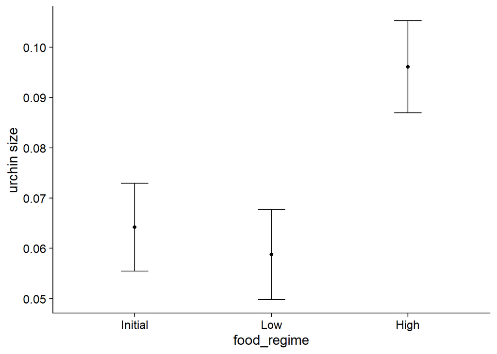

```r
ggplot(plot_data, aes(x = food_regime)) +
  geom_point(aes(y = .pred)) +
  geom_errorbar(aes(ymin = .pred_lower,
                    ymax = .pred_upper),
                width = .2) +
  labs(y = "urchin size")
```

## Model with a different engine 🔗︎

Every one on your team is happy with that plot except that one person who just read their first book on [Bayesian analysis](https://bayesian.org/what-is-bayesian-analysis/). They are interested in knowing if the results would be different if the model were estimated using a Bayesian approach. In such an analysis, a prior distribution needs to be declared for each model parameter that represents the possible values of the parameters (before being exposed to the observed data). After some discussion, the group agrees that the priors should be bell-shaped but, since no one has any idea what the range of values should be, to take a conservative approach and make the priors wide using a Cauchy distribution (which is the same as a t-distribution with a single degree of freedom).

The documentation on the [rstanarm package](https://cran.microsoft.com/web/packages/rstanarm/rstanarm.pdf) shows us that the stan_glm() function can be used to estimate this model, and that the function arguments that need to be specified are called prior and prior_intercept. It turns out that linear_reg() has a stan engine. Since these prior distribution arguments are specific to the Stan software, they are passed as arguments to parsnip::set_engine(). After that, the same exact fit() call is used:

```r
prior_dist <- student_t(df = 1)

bayes_mod <-
  linear_reg() %>%
  set_engine("stan",
             prior_intercept = prior_dist,
             prior = prior_dist)
```

We now train or estimate the model:

```r
set.seed(1123)

bayes_fit <-
  bayes_mod %>%
  fit(width ~ initial_volume * food_regime, data = urchins)
```

We display the analysis:

```r
print(bayes_fit, digits = 5)
```

```
## parsnip model object
##
## Fit time:  24.6s
## stan_glm
##  family:       gaussian [identity]
##  formula:      width ~ initial_volume * food_regime
##  observations: 72
##  predictors:   6
## ------
##                                Median   MAD_SD
## (Intercept)                     0.03310  0.00997
## initial_volume                  0.00155  0.00040
## food_regimeLow                  0.01999  0.01307
## food_regimeHigh                 0.02122  0.01506
## initial_volume:food_regimeLow  -0.00126  0.00050
## initial_volume:food_regimeHigh  0.00055  0.00073
##
## Auxiliary parameter(s):
##       Median  MAD_SD
## sigma 0.02128 0.00182
##
## ------
## * For help interpreting the printed output see ?print.stanreg
## * For info on the priors used see ?prior_summary.stanreg
```

To update the parameter table, the tidy() method is once again used:

```r
tidy(bayes_fit, conf.int = TRUE)
```

```
## # A tibble: 6 x 5
##   term                            estimate std.error  conf.low conf.high
##   <chr>                              <dbl>     <dbl>     <dbl>     <dbl>
## 1 (Intercept)                     0.0331    0.00997   0.0160    0.0494
## 2 initial_volume                  0.00155   0.000403  0.000894  0.00223
## 3 food_regimeLow                  0.0200    0.0131   -0.00250   0.0419
## 4 food_regimeHigh                 0.0212    0.0151   -0.00306   0.0465
## 5 initial_volume:food_regimeLow  -0.00126   0.000497 -0.00214  -0.000387
## 6 initial_volume:food_regimeHigh  0.000552  0.000735 -0.000683  0.00172
```

A goal of the tidymodels packages is that the interfaces to common tasks are standardized (as seen in the tidy() results above). The same is true for getting predictions; we can use the same code even though the underlying packages use very different syntax:

```r
bayes_plot_data <-
  new_points %>%
  bind_cols(predict(bayes_fit, new_data = new_points)) %>%
  bind_cols(predict(bayes_fit, new_data = new_points, type = "conf_int"))
```

```
## Instead of posterior_linpred(..., transform=TRUE) please call posterior_epred(), which provides equivalent functionality.
```

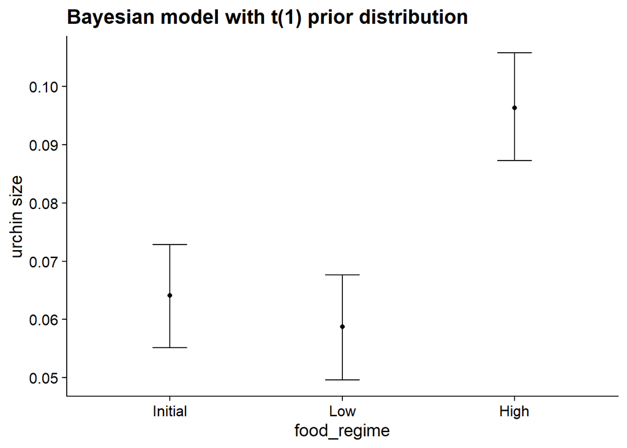

```r
ggplot(bayes_plot_data, aes(x = food_regime)) +
  geom_point(aes(y = .pred)) +
  geom_errorbar(aes(ymin = .pred_lower, ymax = .pred_upper), width = .2) +
  labs(y = "urchin size") +
  ggtitle("Bayesian model with t(1) prior distribution")
```

This isn’t very different from the non-Bayesian results (except in interpretation).

## Why does it work that way?

he extra step of defining the model using a function like linear_reg() might seem superfluous since a call to lm() is much more succinct. However, the problem with standard modeling functions is that they don’t separate what you want to do from the execution. For example, the process of executing a formula has to happen repeatedly across model calls even when the formula does not change; we can’t recycle those computations.

Also, using the tidymodels framework, we can do some interesting things by incrementally creating a model (instead of using single function call). Model tuning with tidymodels uses the specification of the model to declare what parts of the model should be tuned. That would be very difficult to do if linear_reg() immediately fit the model.

If you are familiar with the tidyverse, you may have noticed that our modeling code uses the magrittr pipe (%>%). With dplyr and other tidyverse packages, the pipe works well because all of the functions take the data as the first argument. For example:

```r
urchins %>%
  group_by(food_regime) %>%
  summarize(med_vol = median(initial_volume))
```

```
## # A tibble: 3 x 2
##   food_regime med_vol
##   <fct>         <dbl>
## 1 Initial        20.5
## 2 Low            19.2
## 3 High           15
```

whereas the modeling code uses the pipe to pass around the model object:

[output not shown]